# Introduction to Machine Learning and Data Science

Prediction of Wine Quality

Khizer

2023-03-01

# Introduction

For years, wine quality has been determined by the experts at special festivals, compeitions, and events. We are no expert in wine tasting or determing the quality of the wine, how can we differentiate the wine according to their quality? According to experts, the wine is differentiated according to its smell, flavor, and color, but we are not a wine expert to say that wine is good or bad. What will we do then? Just like any other data-driven decision making, we can make decision or predict the quality of wine using lots of data. Data that has been reported by the experts. The wine quality data from the UCI Machine Learning Repository includes the chemical properties of ‘red’ and ‘white’ wine along with their quality ranging from 0-10. We can train the models using machine learning to understand the distribution and relationship of and between the chemical properties and the quality of wine.

## Description of Dataset

To get a better understanding of the variables:

```
•   volatile acidity :   Volatile acidity is the gaseous acids present in wine.
•   fixed acidity :   Primary fixed acids found in wine are tartaric, succinic, citric, and malic
•   residual sugar :   Amount of sugar left after fermentation.
•   citric acid :    It is weak organic acid, found in citrus fruits naturally.
•   chlorides :   Amount of salt present in wine.
•   free sulfur dioxide :   So2 is used for prevention of wine by oxidation and microbial spoilage.
•   total sulfur dioxide:   Total content of Sulfur dioxide chemical.
•   pH :   In wine pH is used for checking acidity
•   density :   Density of the wine(s).
•   sulphates :    Added sulfites preserve freshness and protect wine from oxidation, and bacteria.
•   alcohol :   Percent of alcohol present in wine.
•   quality :   Quality of the wine ranging from 0-10.
```

This project will guide you through a step-by-step process to use machine learning for the prediction of wine quality using just the chemical properties of wine without a human tasting it.

## Target of this Project

# Data Preparation

In this section, I will mainly analyse the data set, summarize it, and get familiarize myself with the data.

Note that you may need to run the install.packages() commands only once to install the packages on your system, while the library() commands need to be run each time you start a new R session. If we have missed any packages or libraries here, they will come in the later sections.

```r
#Load all the required libraries
#Load all the required packages
# The packages are in hash tags because it might cause trouble while preparing the markdown document
#install.packages("ggplot2")
#install.packages("dplyr")
#install.packages("gridExtra")
#install.packages("GGally")
#install.packages("memisc")
#install.packages("pander")
#install.packages("corrplot")

library("ggplot2")
library("dplyr")
library("gridExtra")
library("GGally")
library("memisc")
library("pander")
library("corrplot")
library("readr")
library("tidyverse")
```

## Load the Data

```r
#Set the working directory
#If you are logged in from a different system just setwd() first to load the data without the need to mention path everywhere

setwd("C:\\Users\\John\\Desktop\\ERASMUS\\Salzburg_Semester1\\Courses\\Data Science and Machine Learning\\Final")

#Loading the csv file(s)

red<-read.csv("winequality-red.csv")
white<-read.csv("winequality-white.csv")
red$wine.type<-"red"
white$wine.type<-"white"
library(dplyr)
library(tidyverse)
library(caret)
wine<-rbind(red,white)

# Checking for NA entries

wine %>% is.na() %>% colSums()
```

```
##        fixed.acidity     volatile.acidity          citric.acid
##                    0                    0                    0
##       residual.sugar            chlorides  free.sulfur.dioxide
##                    0                    0                    0
## total.sulfur.dioxide              density                   pH
##                    0                    0                    0
##            sulphates              alcohol              quality
##                    0                    0                    0
##            wine.type
##                    0
```

```r
# Create a new column called "quality_rating" that determines whether the wine should be poured in the glass or in the sink

wine$quality_rating <- ifelse(wine$quality > 6, "good", "bad")
wine$quality_rating <- as.factor(wine$quality_rating)

# summary of the "wine" data

knitr::kable(str(wine), caption = "Structure and Description of the data")
```

```
## 'data.frame':    6497 obs. of  14 variables:
##  $ fixed.acidity       : num  7.4 7.8 7.8 11.2 7.4 7.4 7.9 7.3 7.8 7.5 ...
##  $ volatile.acidity    : num  0.7 0.88 0.76 0.28 0.7 0.66 0.6 0.65 0.58 0.5 ...
##  $ citric.acid         : num  0 0 0.04 0.56 0 0 0.06 0 0.02 0.36 ...
##  $ residual.sugar      : num  1.9 2.6 2.3 1.9 1.9 1.8 1.6 1.2 2 6.1 ...
##  $ chlorides           : num  0.076 0.098 0.092 0.075 0.076 0.075 0.069 0.065 0.073 0.071 ...
##  $ free.sulfur.dioxide : num  11 25 15 17 11 13 15 15 9 17 ...
##  $ total.sulfur.dioxide: num  34 67 54 60 34 40 59 21 18 102 ...
##  $ density             : num  0.998 0.997 0.997 0.998 0.998 ...
##  $ pH                  : num  3.51 3.2 3.26 3.16 3.51 3.51 3.3 3.39 3.36 3.35 ...
##  $ sulphates           : num  0.56 0.68 0.65 0.58 0.56 0.56 0.46 0.47 0.57 0.8 ...
##  $ alcohol             : num  9.4 9.8 9.8 9.8 9.4 9.4 9.4 10 9.5 10.5 ...
##  $ quality             : int  5 5 5 6 5 5 5 7 7 5 ...
##  $ wine.type           : chr  "red" "red" "red" "red" ...
##  $ quality_rating      : Factor w/ 2 levels "bad","good": 1 1 1 1 1 1 1 2 2 1 ...
```

Table: Structure and Description of the data

```r
knitr::kable(summary(wine),caption = "Summary Statistics the data")
```

Summary Statistics the data

|  | fixed.acidity | volatile.acidity | citric.acid | residual.sugar | chlorides | free.sulfur.dioxide | total.sulfur.dioxide | density | pH | sulphates | alcohol | quality | wine.type | quality_rating |
| --- | --- | --- | --- | --- | --- | --- | --- | --- | --- | --- | --- | --- | --- | --- |
|  | Min. : 3.800 | Min. :0.0800 | Min. :0.0000 | Min. : 0.600 | Min. :0.00900 | Min. : 1.00 | Min. : 6.0 | Min. :0.9871 | Min. :2.720 | Min. :0.2200 | Min. : 8.00 | Min. :3.000 | Length:6497 | bad :5220 |
|  | 1st Qu.: 6.400 | 1st Qu.:0.2300 | 1st Qu.:0.2500 | 1st Qu.: 1.800 | 1st Qu.:0.03800 | 1st Qu.: 17.00 | 1st Qu.: 77.0 | 1st Qu.:0.9923 | 1st Qu.:3.110 | 1st Qu.:0.4300 | 1st Qu.: 9.50 | 1st Qu.:5.000 | Class :character | good:1277 |
|  | Median : 7.000 | Median :0.2900 | Median :0.3100 | Median : 3.000 | Median :0.04700 | Median : 29.00 | Median :118.0 | Median :0.9949 | Median :3.210 | Median :0.5100 | Median :10.30 | Median :6.000 | Mode :character | NA |
|  | Mean : 7.215 | Mean :0.3397 | Mean :0.3186 | Mean : 5.443 | Mean :0.05603 | Mean : 30.53 | Mean :115.7 | Mean :0.9947 | Mean :3.219 | Mean :0.5313 | Mean :10.49 | Mean :5.818 | NA | NA |
|  | 3rd Qu.: 7.700 | 3rd Qu.:0.4000 | 3rd Qu.:0.3900 | 3rd Qu.: 8.100 | 3rd Qu.:0.06500 | 3rd Qu.: 41.00 | 3rd Qu.:156.0 | 3rd Qu.:0.9970 | 3rd Qu.:3.320 | 3rd Qu.:0.6000 | 3rd Qu.:11.30 | 3rd Qu.:6.000 | NA | NA |
|  | Max. :15.900 | Max. :1.5800 | Max. :1.6600 | Max. :65.800 | Max. :0.61100 | Max. :289.00 | Max. :440.0 | Max. :1.0390 | Max. :4.010 | Max. :2.0000 | Max. :14.90 | Max. :9.000 | NA | NA |

```r
# Summary for the quality column

summary(wine$quality)
```

```
##    Min. 1st Qu.  Median    Mean 3rd Qu.    Max.
##   3.000   5.000   6.000   5.818   6.000   9.000
```

```r
table(wine$quality)
```

```
##
##    3    4    5    6    7    8    9
##   30  216 2138 2836 1079  193    5
```

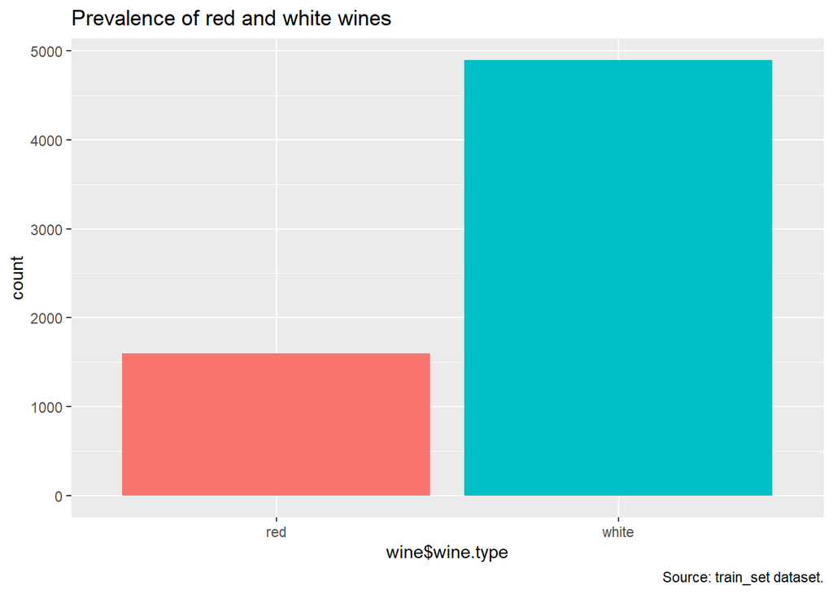

```r
# Histograms

ggplot(data = wine) +
  geom_bar(aes(wine$wine.type, fill = wine$wine.type)) +
  labs(title = "Prevalence of red and white wines",
       caption = "Source: train_set dataset.") +
  theme(legend.position = 'none')
```

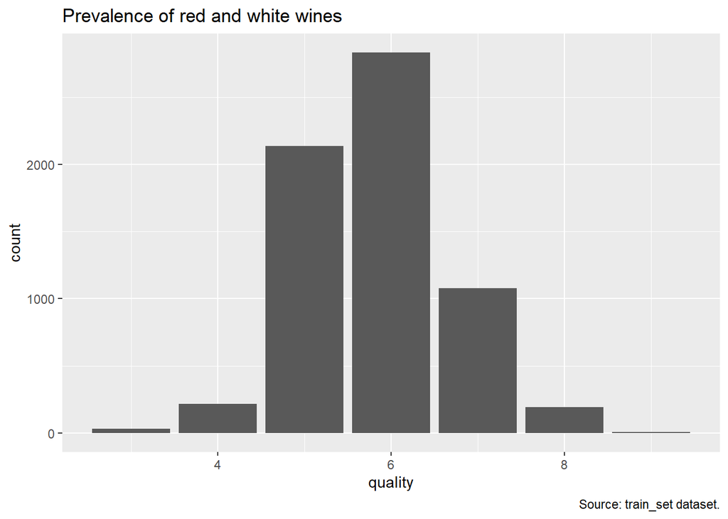

```r
# For quality

ggplot(data = wine) +
  geom_bar(aes(quality, fill = quality)) +
  labs(title = "Prevalence of red and white wines",
       caption = "Source: train_set dataset.") +
  theme(legend.position = 'none')
```

# Summary of the Data (EDA)

This step is to explore the dataset and find the most fitting variables for the model(s) in the later section.

## Test and Train

Before performing the EDA, we must split the data into test set and training set. Although this step can be completed later, we are splitting the data at this step to perform EDA only on the training set. The training set will help machine learn about the parameters and variables that influence the quality of the wine

```r
# Making training and testing data sets

set.seed(3000, sample.kind = "Rounding")
test_index <- createDataPartition(y = wine$quality,
                                  times = 1,
                                  p = 0.3,
                                  list = FALSE)
# Train and test sets for wine type
train_set <- wine[-test_index,]
test_set  <- wine[test_index,]
```

## Summary of the wine - training data

All the EDA will be done on the training data to understand the influence of chemical properties. This section will help us understand the variables that affect the quality of the wine, at the most and at the least.

```r
library(tidyverse)
# Structure and Description of the data
knitr::kable(str(train_set),caption = "Structure and Description of the training data")
```

```
## 'data.frame':    4546 obs. of  14 variables:
##  $ fixed.acidity       : num  7.4 7.8 7.8 11.2 7.4 7.9 7.3 7.8 7.5 6.7 ...
##  $ volatile.acidity    : num  0.7 0.88 0.76 0.28 0.7 0.6 0.65 0.58 0.5 0.58 ...
##  $ citric.acid         : num  0 0 0.04 0.56 0 0.06 0 0.02 0.36 0.08 ...
##  $ residual.sugar      : num  1.9 2.6 2.3 1.9 1.9 1.6 1.2 2 6.1 1.8 ...
##  $ chlorides           : num  0.076 0.098 0.092 0.075 0.076 0.069 0.065 0.073 0.071 0.097 ...
##  $ free.sulfur.dioxide : num  11 25 15 17 11 15 15 9 17 15 ...
##  $ total.sulfur.dioxide: num  34 67 54 60 34 59 21 18 102 65 ...
##  $ density             : num  0.998 0.997 0.997 0.998 0.998 ...
##  $ pH                  : num  3.51 3.2 3.26 3.16 3.51 3.3 3.39 3.36 3.35 3.28 ...
##  $ sulphates           : num  0.56 0.68 0.65 0.58 0.56 0.46 0.47 0.57 0.8 0.54 ...
##  $ alcohol             : num  9.4 9.8 9.8 9.8 9.4 9.4 10 9.5 10.5 9.2 ...
##  $ quality             : int  5 5 5 6 5 5 7 7 5 5 ...
##  $ wine.type           : chr  "red" "red" "red" "red" ...
##  $ quality_rating      : Factor w/ 2 levels "bad","good": 1 1 1 1 1 1 2 2 1 1 ...
```

Table: Structure and Description of the training data

```r
# Summary of the training dataset
knitr::kable(summary(train_set),caption = "Summary Statistics of the training data")
```

Summary Statistics of the training data

|  | fixed.acidity | volatile.acidity | citric.acid | residual.sugar | chlorides | free.sulfur.dioxide | total.sulfur.dioxide | density | pH | sulphates | alcohol | quality | wine.type | quality_rating |
| --- | --- | --- | --- | --- | --- | --- | --- | --- | --- | --- | --- | --- | --- | --- |
|  | Min. : 3.800 | Min. :0.0800 | Min. :0.0000 | Min. : 0.600 | Min. :0.00900 | Min. : 1.00 | Min. : 6.00 | Min. :0.9871 | Min. :2.720 | Min. :0.220 | Min. : 8.00 | Min. :3.000 | Length:4546 | bad :3653 |
|  | 1st Qu.: 6.400 | 1st Qu.:0.2300 | 1st Qu.:0.2500 | 1st Qu.: 1.800 | 1st Qu.:0.03800 | 1st Qu.: 17.00 | 1st Qu.: 77.62 | 1st Qu.:0.9923 | 1st Qu.:3.110 | 1st Qu.:0.430 | 1st Qu.: 9.50 | 1st Qu.:5.000 | Class :character | good: 893 |
|  | Median : 7.000 | Median :0.2900 | Median :0.3100 | Median : 3.100 | Median :0.04700 | Median : 29.00 | Median :118.00 | Median :0.9949 | Median :3.200 | Median :0.510 | Median :10.40 | Median :6.000 | Mode :character | NA |
|  | Mean : 7.225 | Mean :0.3407 | Mean :0.3193 | Mean : 5.497 | Mean :0.05581 | Mean : 30.57 | Mean :115.37 | Mean :0.9947 | Mean :3.218 | Mean :0.531 | Mean :10.51 | Mean :5.817 | NA | NA |
|  | 3rd Qu.: 7.700 | 3rd Qu.:0.4100 | 3rd Qu.:0.3900 | 3rd Qu.: 8.200 | 3rd Qu.:0.06500 | 3rd Qu.: 41.00 | 3rd Qu.:155.00 | 3rd Qu.:0.9970 | 3rd Qu.:3.320 | 3rd Qu.:0.600 | 3rd Qu.:11.30 | 3rd Qu.:6.000 | NA | NA |
|  | Max. :15.900 | Max. :1.5800 | Max. :1.6600 | Max. :65.800 | Max. :0.61100 | Max. :289.00 | Max. :440.00 | Max. :1.0390 | Max. :3.900 | Max. :2.000 | Max. :14.90 | Max. :9.000 | NA | NA |

```r
# Summary to know the distribution of wine as "Good" and "Bad"
knitr::kable(summary(train_set$quality_rating),caption = "Summary of Quality Rating")
```

Summary of Quality Rating

|  | x |
| --- | --- |
| bad | 3653 |
| good | 893 |

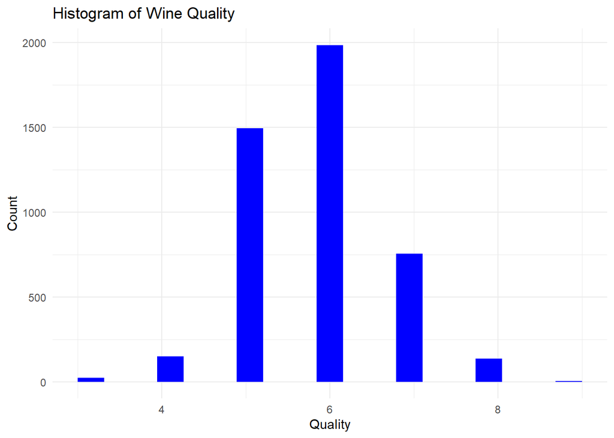

```r
# Histogram for quality distribution in the training set

ggplot(train_set, aes(x = quality)) +
  geom_histogram(fill = "blue", bins = 20) +
  labs(title = "Histogram of Wine Quality",
       x = "Quality", y = "Count") +
  theme_minimal()
```

```r
library(corrgram)
library(corrplot)

# Correlation Table
knitr::kable(cor(train_set[,-c(13,14)]))
```

|  | fixed.acidity | volatile.acidity | citric.acid | residual.sugar | chlorides | free.sulfur.dioxide | total.sulfur.dioxide | density | pH | sulphates | alcohol | quality |
| --- | --- | --- | --- | --- | --- | --- | --- | --- | --- | --- | --- | --- |
| fixed.acidity | 1.0000000 | 0.2230537 | 0.3246945 | -0.1202469 | 0.2977077 | -0.2930931 | -0.3374029 | 0.4504597 | -0.2532104 | 0.3000592 | -0.0935028 | -0.0897453 |
| volatile.acidity | 0.2230537 | 1.0000000 | -0.3726121 | -0.1926785 | 0.3804617 | -0.3393815 | -0.4140572 | 0.2762698 | 0.2601897 | 0.2261568 | -0.0417247 | -0.2574398 |
| citric.acid | 0.3246945 | -0.3726121 | 1.0000000 | 0.1418557 | 0.0485158 | 0.1116563 | 0.1837854 | 0.0963682 | -0.3254213 | 0.0660801 | -0.0085919 | 0.0705229 |
| residual.sugar | -0.1202469 | -0.1926785 | 0.1418557 | 1.0000000 | -0.1289048 | 0.3827263 | 0.4831892 | 0.5520912 | -0.2627167 | -0.1830013 | -0.3580395 | -0.0403116 |
| chlorides | 0.2977077 | 0.3804617 | 0.0485158 | -0.1289048 | 1.0000000 | -0.1902113 | -0.2797489 | 0.3610630 | 0.0430492 | 0.4088584 | -0.2533257 | -0.1950990 |
| free.sulfur.dioxide | -0.2930931 | -0.3393815 | 0.1116563 | 0.3827263 | -0.1902113 | 1.0000000 | 0.7170558 | 0.0123842 | -0.1408918 | -0.1824534 | -0.1756644 | 0.0476805 |
| total.sulfur.dioxide | -0.3374029 | -0.4140572 | 0.1837854 | 0.4831892 | -0.2797489 | 0.7170558 | 1.0000000 | 0.0220009 | -0.2330350 | -0.2744918 | -0.2646305 | -0.0426693 |
| density | 0.4504597 | 0.2762698 | 0.0963682 | 0.5520912 | 0.3610630 | 0.0123842 | 0.0220009 | 1.0000000 | 0.0169364 | 0.2662342 | -0.6853478 | -0.3086292 |
| pH | -0.2532104 | 0.2601897 | -0.3254213 | -0.2627167 | 0.0430492 | -0.1408918 | -0.2330350 | 0.0169364 | 1.0000000 | 0.1874073 | 0.1183644 | 0.0361086 |
| sulphates | 0.3000592 | 0.2261568 | 0.0660801 | -0.1830013 | 0.4088584 | -0.1824534 | -0.2744918 | 0.2662342 | 0.1874073 | 1.0000000 | -0.0119171 | 0.0415486 |
| alcohol | -0.0935028 | -0.0417247 | -0.0085919 | -0.3580395 | -0.2533257 | -0.1756644 | -0.2646305 | -0.6853478 | 0.1183644 | -0.0119171 | 1.0000000 | 0.4508069 |
| quality | -0.0897453 | -0.2574398 | 0.0705229 | -0.0403116 | -0.1950990 | 0.0476805 | -0.0426693 | -0.3086292 | 0.0361086 | 0.0415486 | 0.4508069 | 1.0000000 |

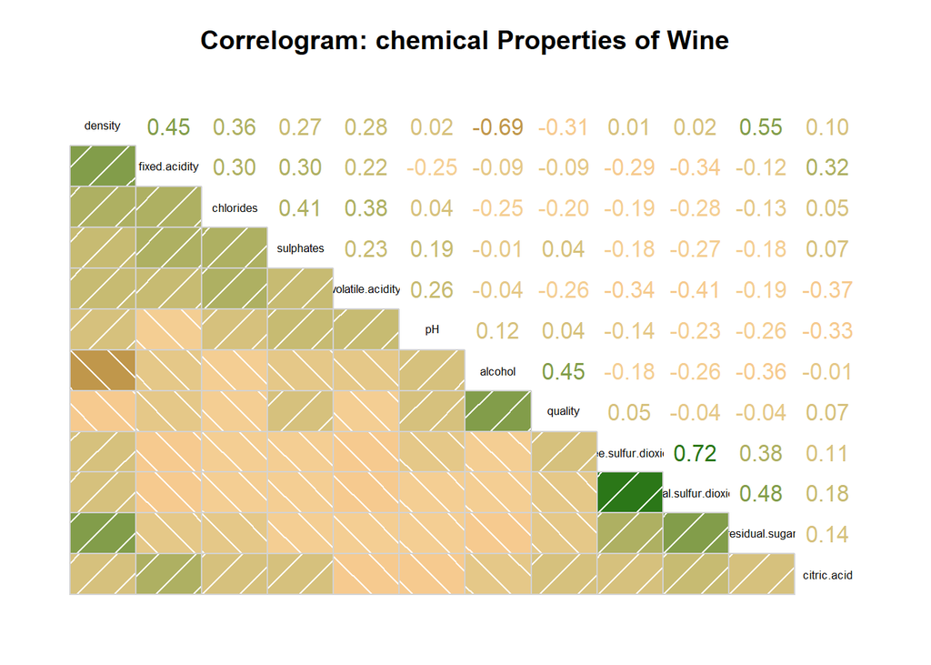

```r
# Corrogram

corrgram(train_set[,-c(13,14)], order=TRUE,
         lower.panel = panel.shade,
         upper.panel = panel.cor,
         text.panel  = panel.txt,
         main = "Correlogram: chemical Properties of Wine",
         col.regions=colorRampPalette(c("darkgoldenrod4", "burlywood1",
                                        "darkkhaki", "darkgreen")))
```

```r
# This function will help you identify the most important properties that has a stronger influence on the quality of the wine

knitr::kable(filterVarImp(x=train_set[,-c(12,13,14)],
                          y=train_set$quality))
```

|  | Overall |
| --- | --- |
| fixed.acidity | 6.074169 |
| volatile.acidity | 17.959134 |
| citric.acid | 4.765756 |
| residual.sugar | 2.719586 |
| chlorides | 13.409144 |
| free.sulfur.dioxide | 3.217762 |
| total.sulfur.dioxide | 2.878926 |
| density | 21.872197 |
| pH | 2.435638 |
| sulphates | 2.803176 |
| alcohol | 34.044142 |

It is evident from this table and the corrogram that the following variables have stronger influence on the quality of the wine compare to rest of them: - Fixed Acidity - Volatile Acidity - Chlorides - Density - Alcohol

These variables will come handy when preparing the model in the later section.

## Data visualization based on wine type

The following graphics are part of the data exploration step. This gives you an opportunity to understand the data well and build a stronger model.

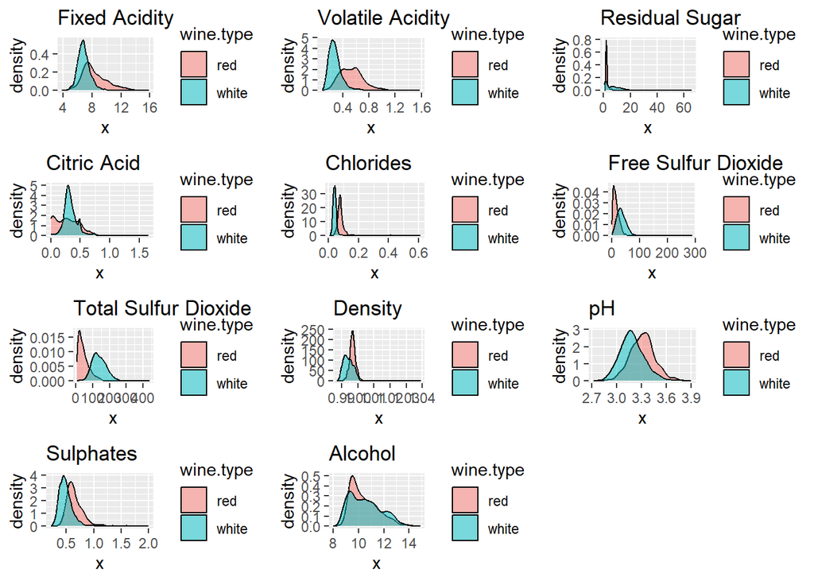

```r
# Build the plots based on wine type
p1<-ggplot(train_set) +
  geom_density(aes_string(x = train_set$fixed.acidity, fill = "wine.type"), alpha = 0.5) +
  ggtitle("Fixed Acidity")
p2<-ggplot(train_set) +
  geom_density(aes_string(x = train_set$volatile.acidity, fill = "wine.type"), alpha = 0.5) +
  ggtitle("Volatile Acidity")
p3<-ggplot(train_set) +
  geom_density(aes_string(x = train_set$residual.sugar, fill = "wine.type"), alpha = 0.5) +
  ggtitle("Residual Sugar")
p4<-ggplot(train_set) +
  geom_density(aes_string(x = train_set$citric.acid, fill = "wine.type"), alpha = 0.5) +
  ggtitle("Citric Acid")
p5<-ggplot(train_set) +
  geom_density(aes_string(x = train_set$chlorides, fill = "wine.type"), alpha = 0.5) +
  ggtitle("Chlorides")
p6<-ggplot(train_set) +
  geom_density(aes_string(x = train_set$free.sulfur.dioxide, fill = "wine.type"), alpha = 0.5) +
  ggtitle("Free Sulfur Dioxide")
p7<-ggplot(train_set) +
  geom_density(aes_string(x = train_set$total.sulfur.dioxide, fill = "wine.type"), alpha = 0.5) +
  ggtitle("Total Sulfur Dioxide")
p8<-ggplot(train_set) +
  geom_density(aes_string(x = train_set$density, fill = "wine.type"), alpha = 0.5) +
  ggtitle("Density")
p9<-ggplot(train_set) +
  geom_density(aes_string(x = train_set$pH, fill = "wine.type"), alpha = 0.5) +
  ggtitle("pH")
p10<-ggplot(train_set) +
  geom_density(aes_string(x = train_set$sulphates, fill = "wine.type"), alpha = 0.5) +
  ggtitle("Sulphates")
p11<-ggplot(train_set) +
  geom_density(aes_string(x = train_set$alcohol, fill = "wine.type"), alpha = 0.5) +
  ggtitle("Alcohol")

# Arrange the ggplots into a grid
grid.arrange(p1, p2,p3,p4,p5,p6,p7,p8,p9,p10,p11, nrow = 4, ncol=3)
```

## Data visualization based on the quality rating

The reason behind choosing the quality_rating instead of the continuous variable of quality is to avoid chaos in the graphs. The quality_rating will help generate smoother graphs.

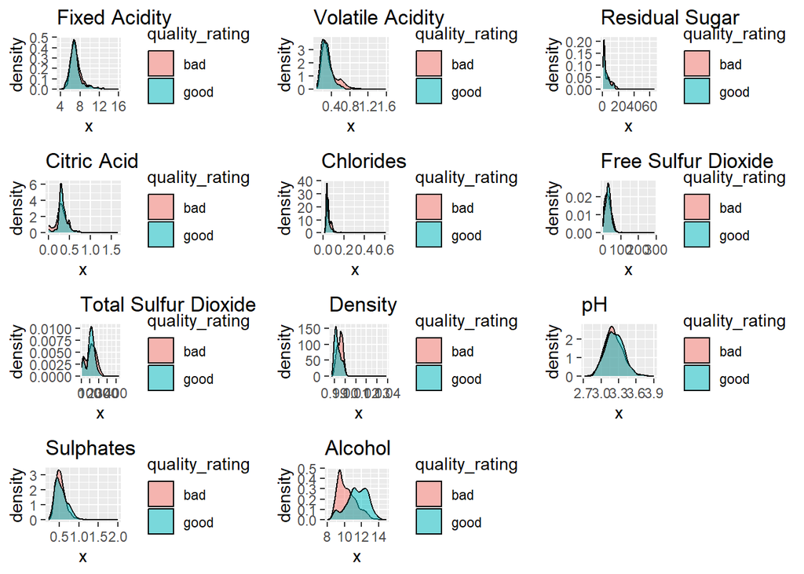

```r
# Build the plots based on quality rating
pp1<-ggplot(train_set) +
  geom_density(aes_string(x = train_set$fixed.acidity, fill = "quality_rating"), alpha = 0.5) +
  ggtitle("Fixed Acidity")
pp2<-ggplot(train_set) +
  geom_density(aes_string(x = train_set$volatile.acidity, fill = "quality_rating"), alpha = 0.5) +
  ggtitle("Volatile Acidity")
pp3<-ggplot(train_set) +
  geom_density(aes_string(x = train_set$residual.sugar, fill = "quality_rating"), alpha = 0.5) +
  ggtitle("Residual Sugar")
pp4<-ggplot(train_set) +
  geom_density(aes_string(x = train_set$citric.acid, fill = "quality_rating"), alpha = 0.5) +
  ggtitle("Citric Acid")
pp5<-ggplot(train_set) +
  geom_density(aes_string(x = train_set$chlorides, fill = "quality_rating"), alpha = 0.5) +
  ggtitle("Chlorides")
pp6<-ggplot(train_set) +
  geom_density(aes_string(x = train_set$free.sulfur.dioxide, fill = "quality_rating"), alpha = 0.5) +
  ggtitle("Free Sulfur Dioxide")
pp7<-ggplot(train_set) +
  geom_density(aes_string(x = train_set$total.sulfur.dioxide, fill = "quality_rating"), alpha = 0.5) +
  ggtitle("Total Sulfur Dioxide")
pp8<-ggplot(train_set) +
  geom_density(aes_string(x = train_set$density, fill = "quality_rating"), alpha = 0.5) +
  ggtitle("Density")
pp9<-ggplot(train_set) +
  geom_density(aes_string(x = train_set$pH, fill = "quality_rating"), alpha = 0.5) +
  ggtitle("pH")
pp10<-ggplot(train_set) +
  geom_density(aes_string(x = train_set$sulphates, fill = "quality_rating"), alpha = 0.5) +
  ggtitle("Sulphates")
pp11<-ggplot(train_set) +
  geom_density(aes_string(x = train_set$alcohol, fill = "quality_rating"), alpha = 0.5) +
  ggtitle("Alcohol")

# Arrange the ggplots into a grid
grid.arrange(pp1, pp2,pp3,pp4,pp5,pp6,pp7,pp8,pp9,pp10,pp11, nrow = 4, ncol = 3)
```

## Scatter plot Matrix

This section strengthens the earlier observation regarding the top 5 influential variables that impacts the wine quality.

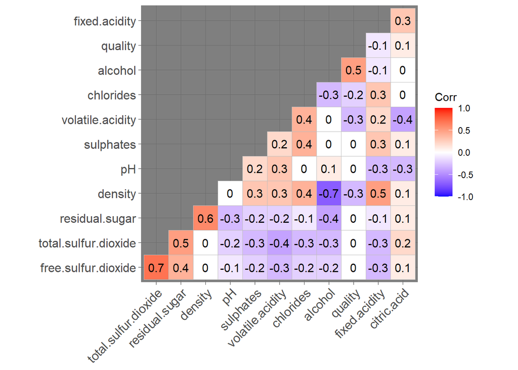

```r
new_data<-train_set[,-c(13,14)]
library(ggcorrplot)
ggcorrplot(new_data %>% cor(),
           hc.order = TRUE, type = "lower",
           lab = TRUE,
           digits = 1,
           ggtheme = ggplot2::theme_dark(),)
```

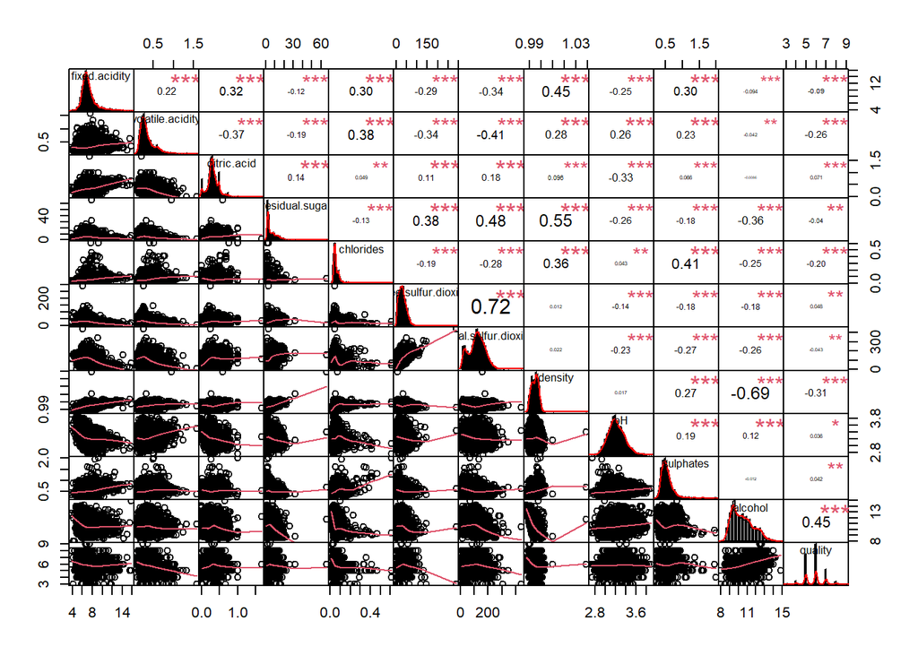

```r
library(PerformanceAnalytics)
chart.Correlation(new_data, hist = T)
```

The preceding figure (Chart Correlation) tells many things. But, in general, it shows four points: scatter plots between each variable, histograms of each variable, correlation values between each value, and p-values between each value against significance value of 0.05.

## Correlation Values

The figure above shows that below relationships have a strong correlation.

[output not shown]

Those perhaps indicate sufficiently high multicollinearity.

# Prediction Problem & Creating Models

### Target Problem

“Based on all the data about the chemical properties, I want to predict if a wine should be poured in the glass (Good quality) or it must be poured in the sink (Very bad quality)”

The quality factors, test data and the training data has been worked out earlier in this project, which means, in this step we are more concerned about training the model only.

#### Based on EDA analysis, we are only going to consider “fixed.acidity”, “volatile.acidity,”chlorides”, “density”, “alcohol”

## Create Models

Only the best fittest model has been selected for this project, while others have been tested and those are not included in this project. Considering the scope of this project, this model fits the best. Although the EDA process points the top 5 variables to be important for the quality prediction, we are going to work with the following linear model.

```r
# Linear regression model using the minimum feature set
model <- lm(quality ~ fixed.acidity+volatile.acidity+alcohol+chlorides+density, data = train_set)
summary(model)
```

```
##
## Call:
## lm(formula = quality ~ fixed.acidity + volatile.acidity + alcohol +
##     chlorides + density, data = train_set)
##
## Residuals:
##     Min      1Q  Median      3Q     Max
## -3.4406 -0.4755 -0.0299  0.4628  2.6743
##
## Coefficients:
##                   Estimate Std. Error t value Pr(>|t|)
## (Intercept)      -45.03332    6.24293  -7.213 6.36e-13 ***
## fixed.acidity     -0.03563    0.01023  -3.482 0.000503 ***
## volatile.acidity  -1.41961    0.07524 -18.867  < 2e-16 ***
## alcohol            0.39985    0.01383  28.921  < 2e-16 ***
## chlorides          0.06503    0.36351   0.179 0.858022
## density           47.63876    6.21287   7.668 2.13e-14 ***
## ---
## Signif. codes:  0 '***' 0.001 '**' 0.01 '*' 0.05 '.' 0.1 ' ' 1
##
## Residual standard error: 0.7485 on 4540 degrees of freedom
## Multiple R-squared:  0.2698, Adjusted R-squared:  0.269
## F-statistic: 335.5 on 5 and 4540 DF,  p-value: < 2.2e-16
```

```r
# Evaluate the model's performance using the testing dataset
predictions <- predict(model, test_set)
mse <- mean((test_set$quality - predictions)^2)
rSquared <- summary(model)$r.squared

# Use the trained model to predict wine quality
newData <- data.frame(fixed.acidity = 0.3, alcohol = 10, volatile.acidity = 0.5, chlorides = 0.7, density = 0.2)
predictedQuality <- predict(model, newdata = newData)
test_set$predicted <- ifelse(predict(model, test_set) > 6, "good", "bad")
test_set$predicted <- as.factor(test_set$predicted)
# Create a confusion matrix
confMatrix <- table(test_set$predicted, test_set$quality_rating)

confusionMatrix(test_set$predicted, test_set$quality_rating, positive = "good")
```

```
## Confusion Matrix and Statistics
##
##           Reference
## Prediction  bad good
##       bad  1172  115
##       good  395  269
##
##                Accuracy : 0.7386
##                  95% CI : (0.7185, 0.758)
##     No Information Rate : 0.8032
##     P-Value [Acc > NIR] : 1
##
##                   Kappa : 0.3517
##
##  Mcnemar's Test P-Value : <2e-16
##
##             Sensitivity : 0.7005
##             Specificity : 0.7479
##          Pos Pred Value : 0.4051
##          Neg Pred Value : 0.9106
##              Prevalence : 0.1968
##          Detection Rate : 0.1379
##    Detection Prevalence : 0.3403
##       Balanced Accuracy : 0.7242
##
##        'Positive' Class : good
##
```

```r
print(confMatrix)
```

```
##
##         bad good
##   bad  1172  115
##   good  395  269
```

# Performance Using Confusion Matrix

```r
# Calculate accuracy
accuracy <- sum(diag(confMatrix)) / sum(confMatrix)
print(paste("Accuracy:", round(accuracy, 3)))
```

```
## [1] "Accuracy: 0.739"
```

```r
# Calculate precision
precision <- diag(confMatrix) / colSums(confMatrix)
print(paste("Precision:", round(precision, 3)))
```

```
## [1] "Precision: 0.748" "Precision: 0.701"
```

```r
# Calculate recall
recall <- diag(confMatrix) / rowSums(confMatrix)
print(paste("Recall:", round(recall, 3)))
```

```
## [1] "Recall: 0.911" "Recall: 0.405"
```

```r
# Calculate F1-score
f1_score <- 2 * precision * recall / (precision + recall)
print(paste("F1-score:", round(f1_score, 3)))
```

```
## [1] "F1-score: 0.821" "F1-score: 0.513"
```

# Prediction Function - Wine Quality: Sink or Glass

```r
# Define a function to predict wine quality
predict_wine_quality <- function(fixed.acidity, volatile.acidity, alcohol, chlorides, density, threshold = 6) {

  # Select the relevant features
  features <- c("fixed.acidity", "volatile.acidity", "alcohol", "chlorides", "density", "quality")

  # Fit a linear regression model
  model <- lm(quality ~ fixed.acidity + volatile.acidity + alcohol + chlorides + density, data = train_set)

  # Make a prediction for the given wine
  prediction <- ifelse(predict(model, data.frame(fixed.acidity, volatile.acidity, alcohol, chlorides, density)) > threshold, "good", "bad")
    # Print a message based on the predicted quality
  if (prediction == "good") {
    print("Pour in the glass!")
  } else {
    print("Drain it in the sink")
  }
  # Return the prediction
  return(prediction)
}
# Check the function
prediction <- predict_wine_quality(fixed.acidity = 7.5, volatile.acidity = 0.6, alcohol = 12.5, chlorides = 0.08, density = 0.999)
```

```
## [1] "Pour in the glass!"
```

```r
### You can test this for different values - play around with this function.
```

You can use this function to evaluate your quality of wine with roughly 75% accuracy. Next time, you have these chemical characteristics you can decide whether this wine should be poured in the sink or into the glass

# Process Elaboration

After downloading and loading the datasets, I was certain about the initial steps; however, I was a bit reluctant with regards to the modelling part. I feel more comfortable with “R”, henceforth, I tried all the EDA and other analysis procedures here. I used a simple technique to load and prepare the data initially. Later, the exploration part was great, as R studion gives you more options to play around with the visualization techniques. After the EDA, a few variables outperformed others; however, they did not make a fitting model to predict the quality of wine.

From the beginning, the idea was to classify the wine as something to pour into the glass = 1 = good or into the sink = 0 = bad. Throughout the project, the idea remained firm and made a reasonable confusion matric at the end.

# Conclusion & Learnings

In conclusion, the process of EDA has always amazed, as it is one of the most interesting step in data analysis. There are so many ways you can perform EDA. Making tables, visualization, and sometimes even both. The top 5 variables that outperformed other variables, include “fixed.acidity”, “volatile.acidity,”chlorides”, “density”, “alcohol content”.

Result from the model with minimum feature sets:

Residual standard error: 0.7485 on 4540 degrees of freedom Multiple R-squared: 0.2698, Adjusted R-squared: 0.269 F-statistic: 335.5 on 5 and 4540 DF, p-value: < 2.2e-16

Performance of the best confusion matrix and the model is as follows:

I have learned so many important concepts and techniques through this project and through the whole course. The idea of creating and evaluating confusion matrix is extremely versatile and applicable everywhere. Also the feature classification and feature engineering are the two fundamental concepts that are the major takeaway from this exercise and from the course. I might have not labelled them in this project, but as you read through the codes and explanation, all the concepts are applied in this project.